# Linear Models and Their Generalizations

Chapter 3- Part 1: ANOVA single-factor model

Katia Meziani

# Motivation

## Toydata

We aim to explain $Y=$ the `Salary` as a function of $x=$`Age`. To do this, we have $n$ observations $(Y_i,x_i)_{i=1,\cdots,n}$, where
$$Y_i=\mu+\beta x_i+\xi_i,\quad
i=1,\cdots,n$$
Here, we plot the relationship between `Age` and `Salary`, using a linear regression to capture the trend across the entire dataset:

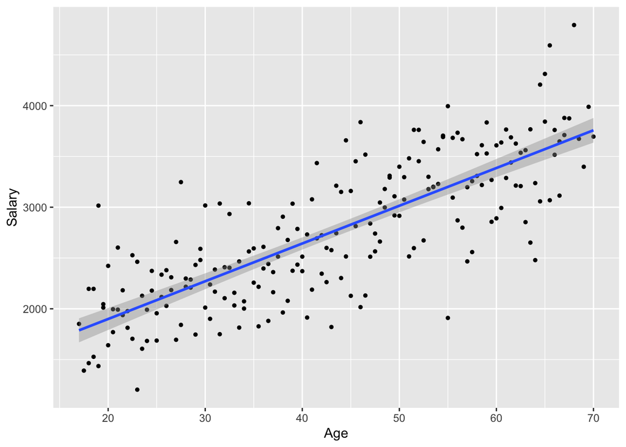

Now, we introduce the categorical variable `Gender` (`M` for male and `F` for female). The salary model for each gender is:
$$Y_{ij}=\mu_{j}+\beta_{j}x_{ij}+\xi_{ij},\quad
j=0,1\quad i=1,\cdots,n_j$$

Here, $\mu_j$ and $\beta_j$ are the intercept and slope for gender $j$. We plot separate regression lines for each gender:

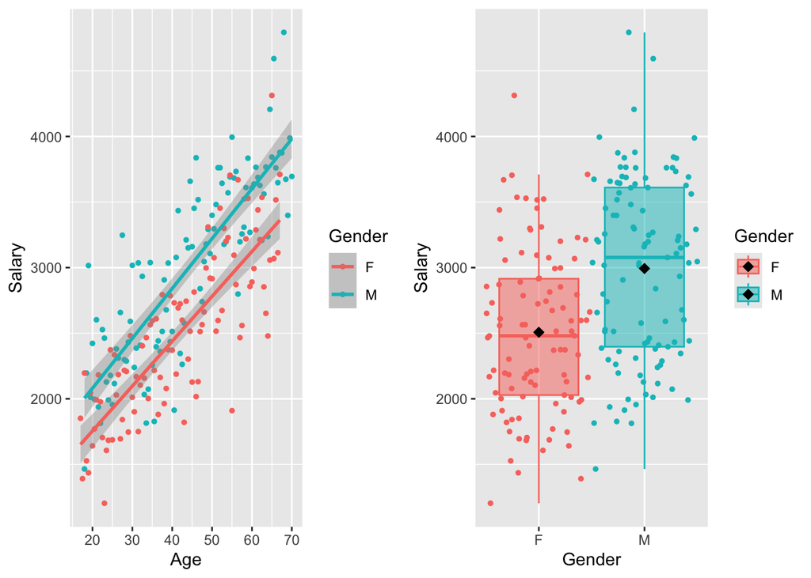

From the plots, we observe the following:

- **Age effect.** Salary tends to increase with age for both genders, but with different rates (slopes).
- **Gender effect.** There is a visible difference in salaries between males and females, with males generally earning more. **This suggests a categorical factor impact**.

Now, let’s simplify the model by considering only the `Gender` factor, without accounting for age:

Now, let’s only consider the Gender factor (without considering age in our model):
$$Y_{ij}=\mu_{j}+\xi_{ij},\quad j=0,1\quad
i=1,\cdots,n_j$$

$\rightarrow$ **This is the one-factor ANOVA model.**

## Intima media dataset

We will work throughout this chapter with the Intima Media dataset.

**Atherosclerosis** is the leading cause of death for men over 35 and women over 45 in most developed countries. It manifests as a thickening and loss of elasticity in the inner walls of the arteries, leading to conditions like myocardial infarction. The arterial wall consists of three layers: the intima, media, and adventitia. **The thickness of the intima-media layer** is a recognized **marker of atherosclerosis**. This measurement was taken ultrasonically from a sample of 110 subjects in 1999 at the Bordeaux University Hospital. Additionally, information about key risk factors, including **smoking** and **alcohol** consumption, was collected from the patients.

```r
library(dbplyr)
marqueur<-read.csv("Intima_Media1.csv")
marqueur$tabac=as.factor(marqueur$tabac)
marqueur$alcool=as.factor(marqueur$alcool)
marqueur$SEXE=as.factor(marqueur$SEXE)
marqueur%>%rmarkdown::paged_table()
```

| SEXE | AGE | taille | poids | tabac | mesure | alcool |
| --- | --- | --- | --- | --- | --- | --- |
| H | 33 | 170 | 70 | OccS | 0.52 | OccD |
| F | 33 | 177 | 67 | RegS | 0.42 | OccD |
| F | 53 | 164 | 63 | OccS | 0.65 | NoD |
| F | 42 | 169 | 76 | OccS | 0.48 | OccD |
| F | 53 | 152 | 54 | NoS | 0.45 | OccD |
| F | 50 | 162 | 53 | RegS | 0.49 | OccD |
| H | 22 | 181 | 72 | NoS | 0.42 | OccD |
| F | 26 | 162 | 61 | OccS | 0.45 | OccD |
| H | 50 | 170 | 80 | NoS | 0.65 | RegD |
| F | 47 | 178 | 73 | NoS | 0.52 | OccD |

[output cut: 100 more lines]

**We want to conduct an analysis of the influence of these factors on the thickness of the intima-media.**

# 1. ANOVA single-factor model

When the regressor is a categorical variable, we refer to the model as an **ANOVA single-factor model**. In this context, we are modeling a quantitative dependent variable $Y$ based on a qualitative explanatory variable (or factor) that has $J \in \mathbb{N}^*$ distinct categories or levels.

Let’s denote: - $Y_{ij}$ as the $i$-th observation that corresponds to the $j$-th level of the factor, and - $n_j$ as the number of observations $Y_{ij}$ associated with level $j$ of the factor, such that:
$$\sum_{j=1}^J n_j = n,$$
where $n$ is the total number of observations in the dataset. In this model, we aim to assess how the different levels of the factor impact the response variable $Y$.

**[The plan]** The plan is said to be

- Complete if $\forall j$, $n_{j}\geq 1$,
- Imcomplete if $\exists j$, $n_{j}=0$,
- Balanced if $\forall j$, $n_{j}=I$.

**Ⓡ** **Example: Dataset Intima Media**

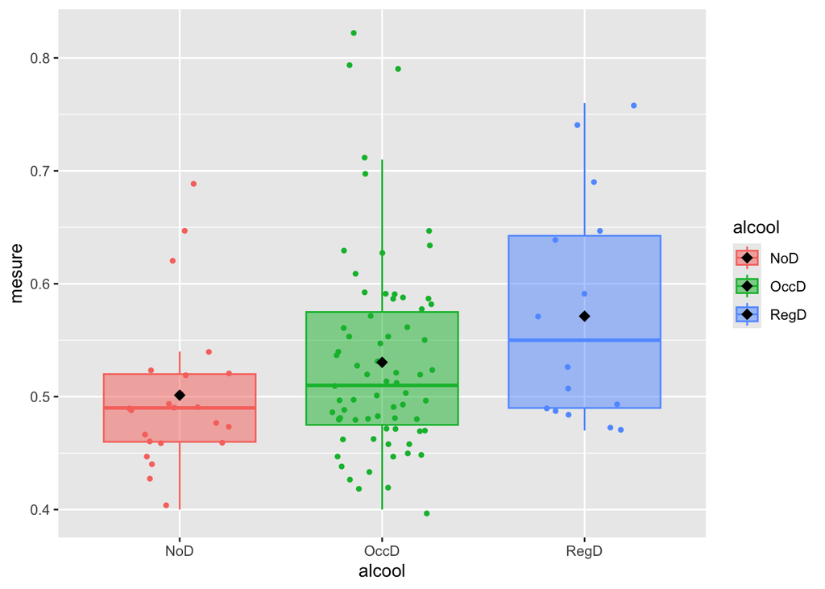

```r
library(ggplot2)
ggplot(marqueur, aes(y=mesure, x=alcool,colour=alcool ,fill=alcool))+
geom_boxplot(alpha=0.5, outlier.alpha=0)+geom_jitter(width=0.25,size=1)+
stat_summary(fun=mean, colour="black", geom="point",shape=18, size=3)
```

📈 The three boxplots suggest that there seems to be an impact of the factor `alcool` on the variable `measure`.

✍**Key points** $\,$ about the graph:

- **The black diamonds** represent the **empirical mean** for each group.
- In the `geom_boxplot` function, the argument `outlier.alpha=0` ensures that **outliers are not plotted twice** (once by `geom_boxplot` and again by `geom_jitter`).
- The `geom_jitter` function is used to **display individual data points without overlapping**. The `width=0.25` argument helps control the spacing of the points for better visualization.

**Ⓡ** **Example: Dataset Intima Media**

```r
Plan_alcool <- as.data.frame(table(marqueur$alcool))
colnames(Plan_alcool) <- c("alcool", "Counts")
Plan_alcool %>%kableExtra::kbl() %>%kableExtra::kable_styling()
```

| alcool | Counts |
| --- | --- |
| NoD | 23 |
| OccD | 71 |
| RegD | 16 |

📈 The plan is complete and unbalanced

## 1.1. Regular Model

| Modality 1 | ⋯ | Modality $j$ | ⋯ | Modality $J$ |
| --- | --- | --- | --- | --- |
| $Y_{i1} = \mu_1 + \epsilon_{i1}$ | ⋯ | $Y_{ij} = \mu_j + \epsilon_{ij}$ | ⋯ | $Y_{iJ} = \mu_J + \epsilon_{iJ}$ |

**[Regular Model]**
We define the **linear Gaussian regression model (ANOVA single-factor model)** in its regular form as follows:
$$\begin{equation*}
\label{eq:Anova1_RM}
\tag{Anova1 [RM]}
Y_{ij}=\mu_j+\epsilon_{ij},\quad i\in\{1,\ldots,n_j\}, \
j\in\{1,\ldots,J\}
\end{equation*}$$
where $\epsilon_{ij}\stackrel{i.i.d.}{\sim}\mathcal{N}(0,\sigma^2).$

📌 **Note**:This assumption can be verified as discussed in the previous chapter.

Now, let’s express our regular ANOVA 1 model in matrix form. To do this, we will use lexicographic ordering to define:
$$\boldsymbol{Y}=\left(
\begin{array}{c}
Y_{11}\\
\vdots\\
Y_{n_11}\\
Y_{12}\\
\vdots\\
Y_{n_22}\\
\vdots\\
Y_{1J}\\
\vdots\\
Y_{n_JJ}
\end{array}
\right)
\in\mathbb{R}^n, \quad
\boldsymbol{\epsilon}=\left(
\begin{array}{c}
\epsilon_{11}\\
\vdots\\
\epsilon_{n_11}\\
\epsilon_{12}\\
\vdots\\
\epsilon_{n_22}\\
\vdots\\
\epsilon_{1J}\\
\vdots\\
\epsilon_{n_JJ}
\end{array}
\right)
\in\mathbb{R}^n,\quad A = \left(
\begin{array}{cccc}
{\Large{\mathbf{1}}}_{n_{1}} & 0 & & \\
0 &
{\Large{\mathbf{1}}}_{n_{2}} & &\vdots\\
\vdots & & \ddots &0\\
& & &
{\Large{\mathbf{1}}}_{n_{J}}\\
\end{array}
\right)\in\mathbb{R}^{n\times J},\quad \boldsymbol{\mu}= \left(
\begin{array}{c}
\mu_{1} \\
\vdots \\
\mu_{J}\\
\end{array}
\right)\in\mathbb{R}^J$$

📌 **Note**: $\text{Rank}(A)=J$,**indicating that $A$ has full rank**. Therefore, our model can be expressed as:

**[Regular Model]**
We define the **linear Gaussian regression model (ANOVA single-factor model)** in its regular matrix form as follows:
$$\begin{equation*}
\label{eq:ANOVA1_RM}
\tag{ANOVA 1 [RM]}
\boldsymbol{Y}=A\boldsymbol{\mu}+\boldsymbol{\epsilon},
\end{equation*}$$
where $\boldsymbol{\epsilon}\sim\mathcal{N}(\boldsymbol{0}_n,\sigma^2\mathbf{I}_n)$

## 1.2. Singular Model

From the regular model ($Y_{ij}=\mu_j+\epsilon_{ij}$), consider the following decompostion of $\mu_j$ :
$$\forall\;j\in\{1,\dots,J\},\quad
\mu_j=\mu+\alpha_j$$
where $(\alpha_j)_j$ represent **the main effect of the factor**.

| Modality 1 | ⋯ | Modality $j$ | ⋯ | Modality $J$ |
| --- | --- | --- | --- | --- |
| $Y_{i1}=\mu+\alpha_1+\epsilon_{i1}$ | ⋯ | $Y_{ij}=\mu+\alpha_j+\epsilon_{ij}$ | ⋯ | $Y_{iJ}=\mu+\alpha_J+\epsilon_{iJ}$ |

**[Singular Model]**
We define the **linear Gaussian regression model (ANOVA single-factor model)** in its singular form as follows:
$$\begin{equation*}
\label{eq:Anova1_SM}
\tag{Anova1 [SM]}
Y_{ij}=\mu+\alpha_j+\epsilon_{ij},\quad i\in\{1,\ldots,n_j\}, \
j\in\{1,\ldots,J\}
\end{equation*}$$
where
$$\epsilon_{ij}\stackrel{i.i.d.}{\sim}\mathcal{N}(0,\sigma^2).$$

Now, let’s express our singular ANOVA 1 model in matrix form. Define:

$$X = \left[{\Large{\mathbf{1}}}_n \
A\right]\in\mathbb{R}^{n\times (J+1)},\quad\boldsymbol{\theta}=
\left(
\begin{array}{c}
\mu\\
\boldsymbol{\alpha}\\
\end{array}
\right)\in\mathbb{R}^{J+1},\quad
\boldsymbol{\alpha}=(\alpha_1,\cdots,\alpha_J)^\top\in\mathbb{R}^{J}$$

📌 **Note**: $\text{Rank}(X)=J$, indicating that it does **not** have full rank.

**[Singular Model]**
We define the **linear Gaussian regression model (ANOVA single-factor model)** in its singular matrix form as follows:
$$\begin{equation*}
\label{eq:ANOVA1_SM}
\tag{ANOVA1 [SM]}
\boldsymbol{Y}=\mu{\Large{\mathbf{1}}}_n+A\boldsymbol{\alpha}+\boldsymbol{\epsilon}=X\boldsymbol{\theta}+\boldsymbol{\epsilon}.
\end{equation*}$$
where $\boldsymbol{\epsilon}\sim\mathcal{N}(\boldsymbol{0}_n,\sigma^2\mathbf{I}_n)$

# 2. Estimation of the Model

**Regular Model (Full Rank Design Matrix)**

In the case where $A$ is a full rank matrix, the estimation of the model parameters is defined as:
$$\widehat{\boldsymbol{\mu}} = \underset{\boldsymbol{\mu}\in
\mathbb{R}^J}{\arg \min} \|\boldsymbol{Y}- A \boldsymbol{\mu}\|^2.$$
The parameter estimates are given by
$$\widehat{\boldsymbol{\mu}} = (A^\top A)^{-1} A^\top \boldsymbol{Y},$$
which is unique due to the full rank of $A$.

**Singular Model (Not Full Rank Design Matrix)**

When the design matrix $X$ is **not** full rank, the estimation is given by:
$$\widehat{\boldsymbol{\theta}} \in \underset{\boldsymbol{\theta}\in
\mathbb{R}^{J+1}}{\arg \min}\|\boldsymbol{Y}-
\boldsymbol{X}\boldsymbol{\theta}\|^2.$$

The parameter estimate $\widehat{\boldsymbol{\theta}}$ is **not unique** since $\boldsymbol{X}$ is not full rank. To obtain a unique solution, a constraint must be imposed:
$$(J+1) - \text{Rank}(\boldsymbol{X}) = (J+1) - J = 1.$$

This constraint ensures that we can identify a specific solution among the infinite possibilities that arise due to the singularity of $\boldsymbol{X}$.

📌 **Note**: For both models, the prediction is unique and can be expressed as:

$$\widehat{\boldsymbol{Y}} = P_X \boldsymbol{Y}=
\boldsymbol{X}\widehat{\boldsymbol{\theta}}, \quad
\widehat{\boldsymbol{Y}} = P_A \boldsymbol{Y}= A
\widehat{\boldsymbol{\mu}}.$$

## 2.1. The Classic used constraints

1. $\mu = 0$.
2. $\alpha_k = 0$ (choice of cell $k$ as the reference cell).
3. $\sum_{j=1}^J \alpha_j = 0$.
4. $\sum_{j=1}^J n_j \alpha_j = 0$ (orthogonality constraint).

📝 **Remarks**

1. **Regular model.** add `-1` in the function `lm`.

   **Ⓡ** `mod0<-lm(mesure~-1+alcool,data=marqueur)`
2. Note that $k=1$ is the default constraint. This is referred to as **Contrast treatment**:.

   **Ⓡ** `mod1<-lm(mesure~alcool, data=marqueur)`

   For $k>1$, it can be adjusted using the `relevel()` function

   **Ⓡ** `marqueur$alcool = relevel(marqueur$alcool, ref="RegD")`  
   `mod2<-lm(mesure~alcool, data=marqueur)`
3. This is known as **Contrast sum**: declare it with `contr.sum`.

   **Ⓡ** `mod3<-lm(mesure~alcool,contrasts=list(alcool="contr.sum"),data=marqueur)`
4. The **orthogonality constraint** is not coded in **Ⓡ** so we need to implement it ourselves.

## 2.2. Theoretical results

**Some notations**

| Empirical Mean of | Definition |
| --- | --- |
| Observations $Y_{ij}$ having the modality $j$ | $\overline{Y}_{\cdot j} = \frac{1}{n_j}\sum_{i=1}^{n_j}Y_{ij}$ |
| All observations $Y_{ij}$ | $\overline{Y}_{\cdot \cdot} = \frac{1}{n}\sum_{j=1}^J\sum_{i=1}^{n_j}Y_{ij} = \frac{1}{n}\sum_{j=1}^J n_j \overline{Y}_{\cdot j}$ |
| All empirical means $\overline{Y}_{\cdot j}$ | $\overline{\overline{Y}}_{\cdot \cdot} = \frac{1}{J}\sum_{j=1}^J \overline{Y}_{\cdot j}$ |

📝 If the plan is balanced, all $n_j$ are equal and $\overline{\overline{Y}}_{\cdot \cdot} = \overline{Y}_{\cdot \cdot}$.  
📝 Under the constraint $\mu = 0$, the OLSE $\widehat{\alpha_j}$ corresponds to $\overline{Y}_{\cdot j}$, the average in the cell $j$.

**Ⓡ** **Example: Dataset Intima Media** To display the empirical mean (EM) for each group defined by the factor `alcool`, we can use the following code.

```r
moy_j<-tapply(marqueur$mesure,list(Alcool=marqueur$alcool), mean)
knitr::kable(moy_j,col.names =c("alcool","Empirical mean"))%>%kableExtra::kable_styling()
```

| alcool | Empirical mean |
| --- | --- |
| NoD | 0.5013043 |
| OccD | 0.5304225 |
| RegD | 0.5712500 |

The empirical mean of the means for each group defined by the factor `alcool` can be calculated as follows:

$\overline{\overline{Y}}_{\cdot\cdot}$= `mean(moy_j)`=0.5343256

Given that the experimental design is unbalanced, the empirical mean $\overline{Y}_{\cdot\cdot}$ of the entire variable `mesure`, is calculated as:

```r
mean(marqueur$mesure)
```

```
## [1] 0.5302727
```

📈  
It is important to note that these two means are not equal. This discrepancy arises from the unbalanced nature of the design, which affects the relationship between the group means and the overall mean.

**[Proposition 1]**  
Let $\mathcal{J} := \{1, \ldots, J\}$. Consider the linear Gaussian regression model (ANOVA single-factor model) in its singular form. For the following constraints, the estimations are as follows

| Constraints/Estimators | $\widehat{\mu}$ | $\widehat{\alpha_j}$ |
| --- | --- | --- |
| $\mu=0$ | $\widehat{\mu}=0$ | $\widehat{\alpha_j} = \overline{Y}_{\cdot j}, \forall j \in \mathcal{J}$ |
| $\alpha_k=0$ | $\widehat{\mu} = \overline{Y}_{\cdot k}$ | $\widehat{\alpha_j} = \overline{Y}_{\cdot j} - \overline{Y}_{\cdot k}, \forall j \in \mathcal{J}$ and $j \neq k$ |
| $\sum_{j=1}^J n_j \alpha_j = 0$ | $\widehat{\mu} = \overline{Y}_{\cdot \cdot}$ | $\widehat{\alpha_j} = \overline{Y}_{\cdot j} - \overline{Y}_{\cdot \cdot}, \forall j \in \mathcal{J},\, j \neq 1$ $\widehat{\alpha_1} = -\left(\sum_{j=2}^{J} n_j \widehat{\alpha_j}\right) / n_1$ |
| $\sum_{j=1}^J \alpha_j = 0$ | $\widehat{\mu} = \overline{\overline{Y}}_{\cdot \cdot}$ | $\widehat{\alpha_j} = \overline{Y}_{\cdot j} - \overline{\overline{Y}}_{\cdot \cdot}, \forall j \in \mathcal{J},\, j \neq 1$ $\widehat{\alpha_1} = -\sum_{j=2}^{J} \widehat{\alpha_j}$ |

*Proof.* In the context of the regular model, we have
$$\widehat{\mu}_j = \overline{Y}_{\cdot j}, \quad \forall j \in \{1,
\ldots, J\}.$$
Since the projection in the regular model is unique, the singular model yields the same estimation:
$$\widehat{y}_{ijk} = \widehat{\mu}_j = \widehat{\mu} +
\widehat{\alpha}_j.$$
By identifying terms, we arrive at the following relation for all $j \in \{1, \ldots, J\}$:
$$\widehat{\mu}_j = \widehat{\mu} + \widehat{\alpha}_j \Leftrightarrow
\widehat{\alpha}_j = \widehat{\mu}_j - \widehat{\mu} =
\overline{Y}_{\cdot j} - \widehat{\mu}.$$
Applying the various constraints to $\widehat{\mu}$ allows us to derive the results.

📝 **Remarks**

- $\mu=0$: It’s correspond to the regular model.
- $\alpha_k=0$: When setting the reference cell to $k$, we find that $\widehat{\mu} = \overline{Y}_{\cdot k}$. The other coefficients $\widehat{\alpha}_j = \overline{Y}_{\cdot j} - \overline{Y}_{\cdot k}$ represent the differential effect between the average of the $j$-cell and the average of the reference cell $k$.}
- $\sum_{j=1}^J n_j \alpha_j = 0$: Here, the fixed effect is estimated as $\widehat{\mu} = \overline{Y}_{\cdot \cdot}$, which denotes the overall empirical average. The coefficients $\widehat{\alpha}_j = \overline{Y}_{\cdot j} - \overline{Y}_{\cdot \cdot}$ highlight the differential effect between the average of the $j$-cell and the overall empirical average (considered as the reference cell).
- $\sum_{j=1}^J \alpha_j = 0$: In this case, the fixed effect is estimated by $\widehat{\mu} = \overline{\overline{Y}}_{\cdot \cdot}$, which is the mean of the empirical means across all cells. The coefficients $\widehat{\alpha}_j = \overline{Y}_{\cdot j} - \overline{\overline{Y}}_{\cdot \cdot}$ indicate the differential effect between the average of the $j$-cell and the average of the empirical averages (serving as the reference cell).}

**Ⓡ** **Example: Dataset Intima Media**

**Implement constraint with $\mu=0$**

```r
mod0<-lm(mesure~-1+alcool,data=marqueur);mod0
```

```
##
## Call:
## lm(formula = mesure ~ -1 + alcool, data = marqueur)
##
## Coefficients:
##  alcoolNoD  alcoolOccD  alcoolRegD
##     0.5013      0.5304      0.5713
```

📝 $\widehat\mu=0$, $\quad\widehat\alpha_1=\overline{Y}_{\cdot1}=0.5013043$, $\quad\widehat\alpha_2=\overline{Y}_{\cdot2}=0.5304225$ and $\quad\widehat\alpha_3=\overline{Y}_{\cdot3}=0.57125$

**Implement constraint with $\alpha_1=0$ (Constrast treatment: by default)**

```r
mod1<-lm(mesure~alcool, data=marqueur);mod1
```

```
##
## Call:
## lm(formula = mesure ~ alcool, data = marqueur)
##
## Coefficients:
## (Intercept)   alcoolOccD   alcoolRegD
##     0.50130      0.02912      0.06995
```

```r
marqueur$alcool = relevel(marqueur$alcool, ref="RegD")
mod2<-lm(mesure~alcool, data=marqueur)
```

**Implement constraint sum : $\sum_{j=1}^J \alpha_j = 0$**

```r
modCS<-lm(mesure~alcool,contrasts=list(alcool="contr.sum"),data=marqueur);modCS
```

```
##
## Call:
## lm(formula = mesure ~ alcool, data = marqueur, contrasts = list(alcool = "contr.sum"))
##
## Coefficients:
## (Intercept)      alcool1      alcool2
##    0.534326    -0.033021    -0.003903
```

⚠️ Here,**Ⓡ** does **rename** the modalities.

**Unbiased estimator of $\sigma^2$**

**[Proposition 2]**

Consider the linear Gaussian regression model (ANOVA single-factor model) in its singular form under the posutlats **[P1]–[P3]**. For any classical constraint, an unbiased estimator of $\sigma^2$ is
$$\widehat\sigma^2=\frac{\|\boldsymbol{Y}-\widehat{\boldsymbol{Y}}\|^2}{n-J}=\frac{1}{n-J}\sum_{j=1}^J\sum_{i=1}^{n_j}(Y_{ij}-
\overline{Y}_{\cdot j})^2,$$
where $\widehat{\boldsymbol{Y}}=P_\boldsymbol{X}\boldsymbol{Y}=P_A\boldsymbol{Y}$

Moreover, under the gaussian assumption **[P4]**
$$\frac{(n-J)\widehat\sigma^2}{\sigma^2}\sim\chi^2(n-J).$$

*Proof.* Immediate according to previous Chapters.$\square$

📌 **Note**: Whether we consider the regular or the singular model, we have the equality of ranks:
$$\text{Rank}(A) = \text{Rank}(\boldsymbol{X}) = J.$$

## 2.3. Global Fisher test

To test the impact or influence of the factor on the response variable $\boldsymbol{Y}$.

**[Theorem 1]**
Consider the singular model under **[P1]–[P4]**, i.e., $\epsilon\sim\mathcal{N}(0_n,\sigma^2\mathbf{I}_n)$. We aim to test the following hypotheses:
$$\mathcal{H}_0 :
\ \boldsymbol{Y}=\mu{\Large{\mathbf{1}}}_n+\epsilon\quad\mbox{vs}\quad
\mathcal{H}_1 : \
\boldsymbol{Y}=\mu{\Large{\mathbf{1}}}_n+A\alpha+\epsilon$$

Under the null hypothesis $\mathcal{H}_0$, we define the statistic:
$$F=\frac{\|P_{1_n}\boldsymbol{Y}-P_{X}\boldsymbol{Y}\|^2/(J-1)}{\widehat\sigma^2}.
\sim {{\Large{\mathcal{F}}}}_{(J-1,n-J)}.$$
A test of size $\alpha\in(0,1)$ for $\mathcal{H}_0$ against $\mathcal{H}_1$ is given by:
$$\{F>q^{{{\Large{\mathcal{F}}}}_{(J-1,n-J)}}_{1-\alpha}\}.$$
where $q^{{{\Large{\mathcal{F}}}}_{(J-1,n-J)}}_{1-\alpha}\}.$ is the quantile of order $1-\alpha$ of the fisher distribution ${\Large{\mathcal{F}}}_{(J-1,n-J)}$.

*Sketch of proof.*

First, observe that the following relationship holds:
$$\text{Rank}(\boldsymbol{X})-\text{Rank}({\Large{\mathbf{1}}}_n)=\text{Rank}([{\Large{\mathbf{1}}}_n
\ A])-\text{Rank}(1_n)=J-1.$$

According to the proposition 2 regarding the unbiased estimator of $\sigma^2$, we have:
$$\frac{(n-J)\widehat\sigma^2}{\sigma^2}\sim\chi^2(n-J).$$
Finally, we conclude the proof by applying the Nested Theorem from Chapter 2.$\square$

📌 **Note**: The statistic $F$ can be expressed as:
$$F=\frac{\sum_{j=1}^Jn_j(\overline{Y}_{\cdot j}-\overline{Y}_{\cdot\cdot
})^2}{\sum_{j=1}^J\sum_{i=1}^{n_j}(Y_{ij}- \overline{Y}_{\cdot
j})^2}\times\frac{(n-J)}{(J-1)}=\frac{(\text{RSS}_{\mathcal{H}_0}-\text{RSS})/(J-1)}{\text{RSS}/(n-J)}$$
where
$$\begin{eqnarray*}
\text{RSS}&=&\|\boldsymbol{Y}-P_\boldsymbol{X}\boldsymbol{Y}\|^2=
\|Y-P_{[{\Large{\mathbf{1}}}_n
\ A]}Y\|^2=\|\boldsymbol{Y}-P_A\boldsymbol{Y}\|^2=\sum_{j=1}^J\sum_{i=1}^{n_j}(Y_{ij}-\overline{Y}_{\cdot
j})^2\\
\text{RSS}_{\mathcal{H}_0}&=&\|\boldsymbol{Y}-P_{1_n}\boldsymbol{Y}\|^2=\sum_{j=1}^J\sum_{i=1}^{n_j}(Y_{ij}-\overline{Y}_{\cdot\cdot
})^2=\text{TSS}.
\end{eqnarray*}$$

**Ⓡ** **Example: Dataset Intima Media** The other outputs from the summary can be interpreted in the same way, including the Student’s t-tests, Fisher’s tests, $R^2$, and adjusted $R^2_a$,.. as well as the diagnostic plots and outliers.

```r
summary(mod1)
```

```
##
## Call:
## lm(formula = mesure ~ alcool, data = marqueur)
##
## Residuals:
##      Min       1Q   Median       3Q      Max
## -0.13042 -0.05814 -0.02042  0.03642  0.28958
##
## Coefficients:
##             Estimate Std. Error t value Pr(>|t|)
## (Intercept)  0.50130    0.01772  28.298   <2e-16 ***
## alcoolOccD   0.02912    0.02038   1.429   0.1561
## alcoolRegD   0.06995    0.02766   2.529   0.0129 *
## ---
## Signif. codes:  0 '***' 0.001 '**' 0.01 '*' 0.05 '.' 0.1 ' ' 1
##
## Residual standard error: 0.08496 on 107 degrees of freedom
## Multiple R-squared:  0.05641,    Adjusted R-squared:  0.03877
## F-statistic: 3.198 on 2 and 107 DF,  p-value: 0.04477
```

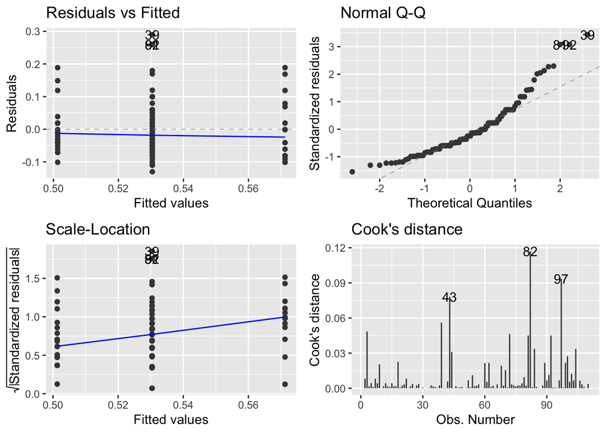

```r
library(ggfortify)
autoplot(mod1,1:4)
```

# 3. Comparison of Modalities

In many analyses, we seek to compare the effects of different modalities (or treatments) of a factor on a response variable. While constraints such as $\alpha_k = 0$ allow us to evaluate the effect of a single modality against a reference modality, we express this in the singular model as:
$$Y_{ij} = \mu + \alpha_j + \xi_{ij} \quad \Rightarrow \quad
\widehat{\mu} = \overline{Y}_{\cdot k}\quad \text{and}\quad
\widehat{\alpha_j}=\overline{Y}_{\cdot j}-\overline{Y}_{\cdot k}$$
However, these constraints do not adequately account for the complexities involved in making pairwise comparisons among all modalities. This necessity for a comprehensive comparison among multiple treatments leads us to explore multiple testing methods.

Suppose we want to compare modalities $j$and $j'$:
$$\mathcal{H}_0^{jj'} : \mu_j = \mu_{j'} \quad \textit{vs} \quad
\mathcal{H}_1^{jj'} : \mu_j \neq \mu_{j'}$$
This can be framed as testing the nullity of a constraint $c^\top \boldsymbol{\mu}$, where
$$c = (0, \ldots , \underbrace{1}_{j},0,
\ldots,0, ,\underbrace{ -1}_{j'},0, \ldots,0)^\top.$$
The test statistic is given by:
$$T = \frac{c^\top \widehat{\boldsymbol{\mu}}}{\sqrt{\widehat{\sigma}^2
c^\top (A^\top A)^{-1} c}} = \frac{\widehat{\mu}_j -
\widehat{\mu}_{j'}}{\sqrt{\widehat{\sigma}^2 c^\top (A^\top A)^{-1}
c}} \sim t_{n-r}$$
Where
$$A^\top A =
\begin{pmatrix}
n_1 & & \\
& \ddots & \\
& & n_J
\end{pmatrix}$$
Thus, we have:
$$c^\top (A^\top A)^{-1} c = \frac{1}{n_j} + \frac{1}{n_{j'}}$$
Therefore, the test statistic simplifies to:
$$T = \frac{\widehat{\mu}_j -
\widehat{\mu}_{j'}}{\sqrt{\widehat{\sigma}^2 \left( \frac{1}{n_j} +
\frac{1}{n_{j'}} \right)}} \sim t_{n-J}$$

This allows us to construct a test at level $\alpha$.

**When comparing multiple modalities**, we face the challenge of testing **several hypotheses simultaneously**. Specifically, we are interested in identifying pairs $(j, j')$ such that $\mu_j \neq \mu_{j'}$. This leads to $\frac{J(J-1)}{2}$ tests, each with a significance level $\delta$:
$$\mathcal{H}^{j j'}_0 : \mu_j = \mu_{j'} \quad \textit{vs} \quad
\mathcal{H}^{j j'}_1 : \mu_j \neq \mu_{j'}$$

For each test, we control the Type I error rate, i.e., the probability of incorrectly rejecting $\mathcal{H}^{j j'}_0$ when it is true (should be $\leq \delta$). We can calculate the probability of $\mathcal{E}$=*“making at least one Type I error”*:
$$P\left(\mathcal{E}\right) \leq \sum_{j,j', j < j'}
P_{\mathcal{H}^{j j'}_0}(\text{reject } \mathcal{H}^{j j'}_0)
\leq \sum_{j,j', j < j'} \delta \leq \frac{J(J-1)}{2} \delta$$

For example, if $J = 7$ and $\delta = 5\%$, the probability of making at least one Type I error could reach $1$, indicating a lack of control over the overall error rate.

To address this issue, we can apply the **Bonferroni Method**, which adjusts the significance level for each individual test. Each test will be conducted at a new significance level of $\frac{2\delta}{J(J-1)}$, ensuring that the overall error rate remains at $\delta$. However, this adjustment makes it more challenging to reject the null hypotheses.

**Ⓡ**  
**Example** Let’s examine the influence of the `Statut` of a tree (alder trees) on its `Diametre`. The `Statut` has three modalities: `codominant` (the same height as one or more neighboring trees), `dominant` (taller than neighboring trees), and `dominated` (shorter than one or more neighboring trees). We can visualize this relationship using a boxplot:

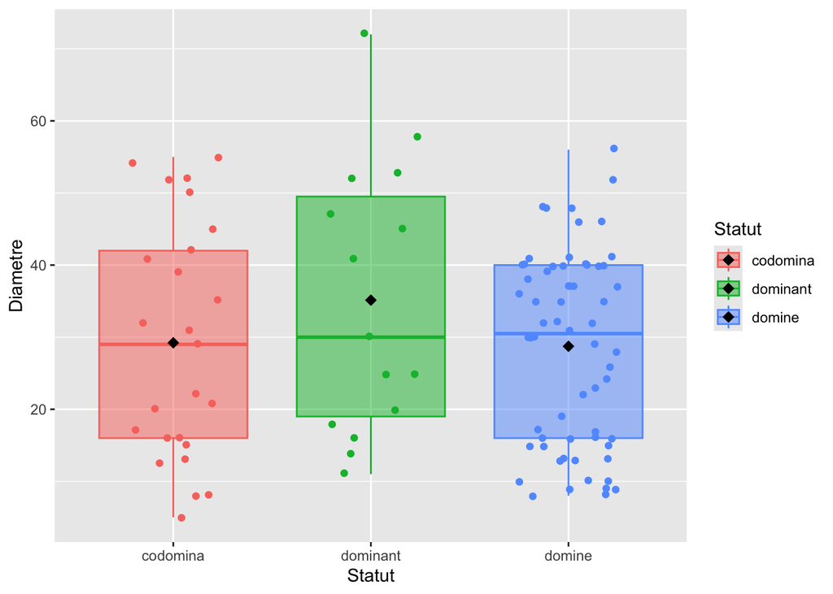

```r
library(ggplot2)

# Load the data
arbres = read.table("arbres.txt", header=FALSE, sep="")
colnames(arbres) = c("Diametre", "Statut")

# Create the boxplot with jitter
ggplot(arbres, aes(y=Diametre, x=Statut, colour=Statut, fill=Statut)) +
  geom_boxplot(alpha=0.5, outlier.alpha=0) +
  geom_jitter(width=0.25) +
  stat_summary(fun=mean, colour="black", geom="point", shape=18, size=3)
```

From the boxplot, we observe an effect of the `Statut` factor on the `Diametre`. To further analyze this effect, we can conduct multiple pairwise tests:

```r
pairwise.t.test(arbres$Diametre, arbres$Statut,
                 p.adjust.method="bonferroni")
```

```
##
##  Pairwise comparisons using t tests with pooled SD
##
## data:  arbres$Diametre and arbres$Statut
##
##          codomina dominant
## dominant 0.67     -
## domine   1.00     0.41
##
## P value adjustment method: bonferroni
```

📈 The output summarizes the results of pairwise t-tests conducted to compare the `Diametre` of trees based on their `Statut` (status). Here’s a breakdown of the comparisons:

- **`codominant` vs. `dominant`**: The p-value is **0.67** and suggests that there is no significant difference in the diameters of trees classified as `codominant` compared to those classified as `dominant`. Since the p-value is greater than the typical alpha level of 0.05, we fail to reject the null hypothesis for this comparison.
- **`codominant` vs. `dominated`**: The p-value is **1.00** and indicates an extremely high probability of observing the data if there were no actual differences in diameters. Therefore, we conclude that there is no significant difference in the diameters of `codominant` trees compared to `dominated` trees.
- **`dominant` vs. `dominated`** : The p-value is **0.41** and indicates no significant difference in diameter between `dominant` and `dominated` trees. Again, this is above the threshold for significance, leading us to fail to reject the null hypothesis for this comparison.

**Overall**, the analysis suggests that there are **no statistically significant differences** in the diameters of trees among the different `Statut` categories (`codominant`, `dominant`, and `dominated`) when applying the Bonferroni adjustment method for multiple comparisons. This means that, based on this analysis, the effect of the `Statut` on `Diametre` is not statistically significant.

📝 In addition to the Bonferroni method, there are other approaches for conducting multiple tests, such as the Tukey and Scheffé methods. However, these will not be covered in this course.